# Devoir 1

Aloui Mohamed, Jafuno Douba

26 novembre 2018

## Compte rendu du devoir 1

## Les données

On considère un tableau de données sur des personnes anorexiques qui ont été suivies pendant quelque temps. Certains patients ont suivi une thérapie (soit une thérapie familiale ‘FT’, soit la thérapie *Cognitive Behavioural Treatment* ‘CBT’), d’autres n’ont suivi aucun traitement (c’est le groupe de contrôle ‘Cont’). Le tableau contient pour chaque individu le type de la thérapie et son poids au début et à la fin de l’étude (en livres).

1. Téléchargez le fichier *DonneesAnorexie.txt* et importez les données sous forme d’un tableau (dataframe). Familiarisez-vous avec les données.
2. Changez l’unité de mesure du livre au kilogramme (1 livre = 0.453 kg).

## Analyse des données

Ce tableau de données sur l’anorexie a été établi lors d’une étude clinique. L’objectif de l’étude est de comparer les trois types de traitements et leurs effets sur les patients. Quelle thérapie est la plus efficace ? Est-ce que certains traitements n’ont pas de résultat positif (voire ont des résultats négatifs) sur la santé des patients ?

Nous formulons ici quelques questions précises, auxquelles vous devez réfléchir et chercher des réponses en utilisant des outils de la statistique descriptive, notamment des représentations graphiques et des indicateurs statistiques. C’est à vous de choisir les bons outils pour répondre aux cinq questions suivantes.

## Question 1

Tout d’abord, on veut savoir si l’étude a été correctement menée. En particulier, on veut vérifier si la composition des trois groupes de patients qui suivent des traitements différents à été bien faite. Plus précisément, afin de pouvoir comparer les résultats, il faut qu’au début de l’étude les trois groupes soient similaires. Comparer les nombres de patients par groupe, et comparer les distributions du poids des patients au début de l’étude.

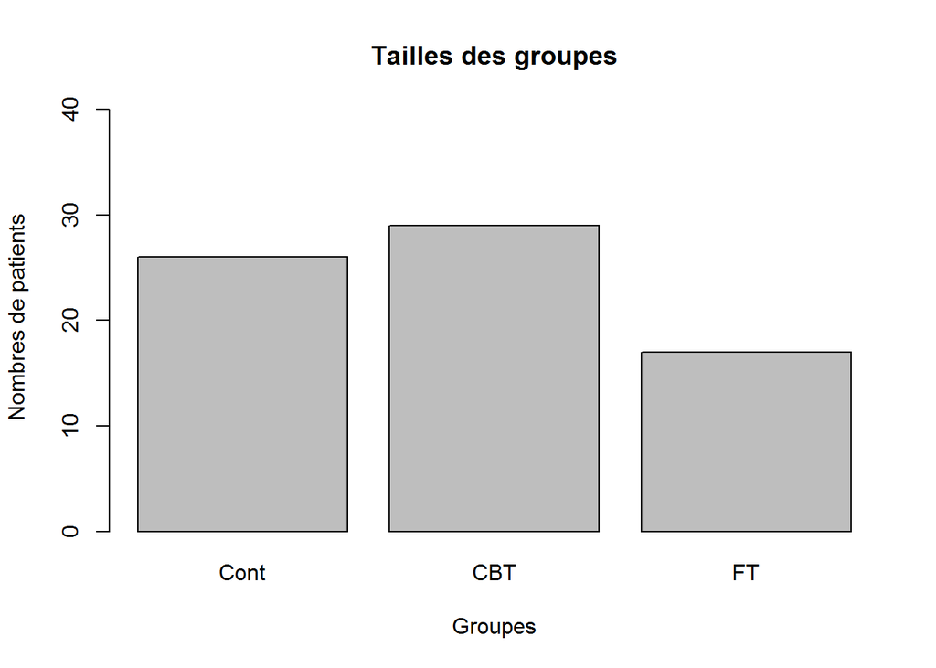

On voit que notre jeu de données anoréxie est constitué de **72** patients anorexiques dont:

**29** patients dans le goupe **CBT**

**26** patients dans le groupe **Cont**

**17** patients dans le groupe **FT**

**Concernant les distributions du poids des patients au début de l’étude On observe l’histogrammes suivant:**

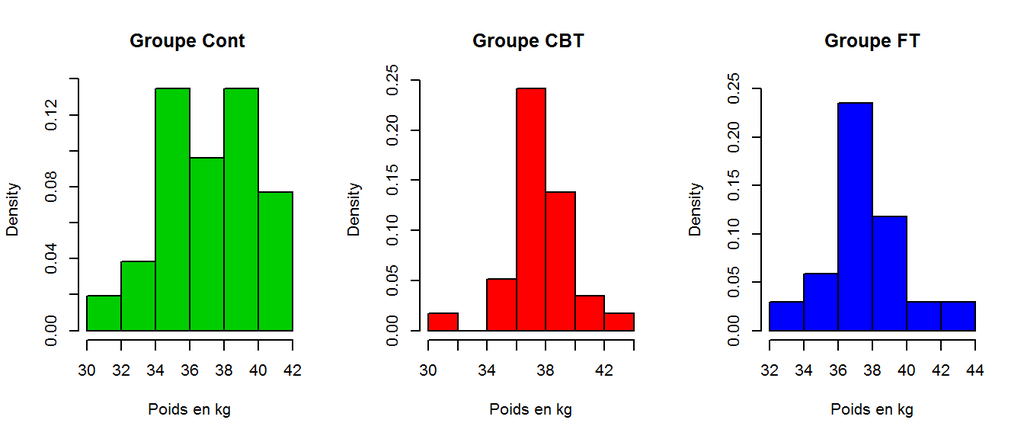

On voit que l’ensembles des classes des histogrammes sont entre 30kg et 44kg les patients sont belles et bien anorexiques, On remarque que les histogrammes de **CBT** et **FT** sont à peu près semblables. Les distributions du poids sont assez homogène pour les personnes des 3 groupes. En tendance centrale, le taux le plus élevé est la classe [36-38[pour les patients des groupes **CBT** et **FT** et les classes [34,36[ [38,40[ pour les patients du groupes **Cont** dont la distribution du poids est légerement étalé vers la droite au dela de 34kg.

**On considère maintenant les 3 QQplotS comparant la distibution du poids avant l’étude dans chaque groupe**

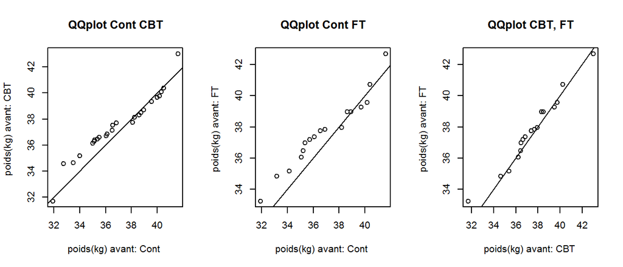

On observe que dans chaque qqplots ont ne peut pas rejeter l’hypothèse que les distributions du poids avant l’étude semblent équilibrées les points s’allignent à peu près autour de la bissectrice surtout pour le 3ème qq plots les distributions du poids avant le traitement semble etre semblable pour **CBT** et **FT** pour les 2 premiers qqplots certains points s’éloignent un peu.

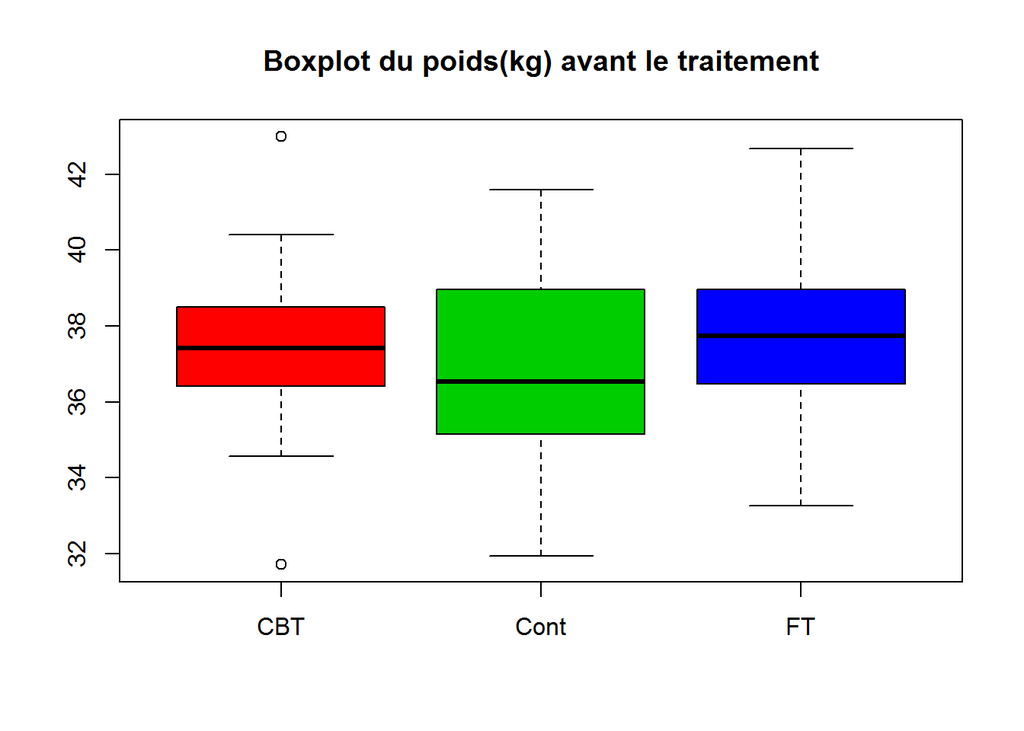

les trois groupes ne sont pas identiques au début de l’étude notamment à cause leurs tailles.

## Question 2

Vu que les trois groupes ne sont pas identiques au début de l’étude, il se pose la question de savoir comment évaluer le succès d’un traitement. Est-ce raisonnable de comparer simplement le poids des patients à la fin de l’étude ? Ou ne serait-il pas plus pertinent de comparer les variations de poids durant l’étude (c’est-à-dire les prises/pertes de poids) ?

Non il n’est pas raisonnable de comparer seulement le poids des patients à la fin de l’étude. On sais deja qu’au début de l’étude les 3 groupes sont différents nottament par leurs tailles,en effet étonnamment les trois groupes ne sont pas de taille égale. Cela peut signifier que certains patients ont décroché ou que c’était une étude d’observation sans répartition aléatoire des participants, sinon une autre explication pourrait être donnée. Ceci doit être pris en compte lors de l’interprétation des résultats. Il serait donc plus raisonnable de considerer que les résultats des trois groupes peuvent être attribuée aux différences individuelles initiales de chaque patients entre les observations et ainsi il serait donc plus pertinent de comparer les variations de poids durant l’étude Si on veut savoir si les groupes ont influencé la prise de poids de nos patients.

## Question 3

Le groupe de contrôle (**‘Cont’**) est constitué de patients qui n’ont pas suivi de traitement particulier. Comment a évolué le poids de ses patients durant l’étude ?

Pour cela on effectue un nuage de point entre la prise/perte de Poids après l’étude et le poids au debut de l’étude pour les patients du groupe **Cont** ceux qui n’ont pas suivi de traitement

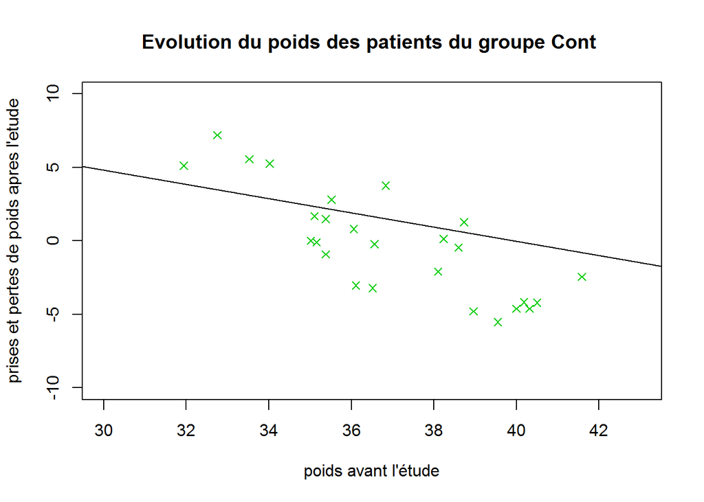

Le nuage de point nous montre une relation linéaire(corrélation) négative, notre poids diminue après l’étude lorque notre poids avant l’étude devient plus important en ce qui concerne les patients du groupe **Cont** donc plus je suis maigre au début de l’étude plus mon poids va augmenter après l’étude et plus j’ai un poids important au début de l’étude plus mon poids va diminuer après l’étude

**Observons maintenant le Boxplot liée à la prise/perte de poids pour le groupe Cont**

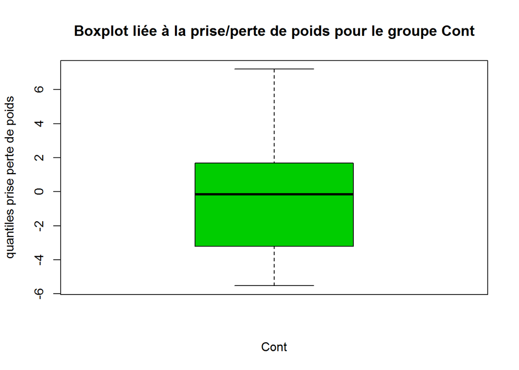

Résumé Boxplot de Cont

```
##    Min. 1st Qu.  Median    Mean 3rd Qu.    Max.
## -5.5266 -3.1710 -0.1585 -0.2039  1.6308  7.2027
```

On observe que la moyenne est de -0.2039 donc durant l’étude il n’y a pas d’augmentation significative du poids pour les patients du groupe Cont au contraire, nous avons donc en moyenne une perte de poids qui n’est pas importante pour les patients du groupes Cont durant l’étude.

## Question 4

Etudier l’impact des différents traitements sur le poids des patients. Comparer les trois méthodes. Quel traitement semble le meilleur ?

On essaye maintenant de tester si le changement de poids avant-après traitement diffère selon le traitement reçu. Plus précisément, on veut tester la différence entre les 3 traitements**Cont**, **CBT** et **FT**.

**Pour étudier l’impact des différents traitements sur le poids des patients observons le nombre de patients par groupes qui ont pris et perdu du poids**

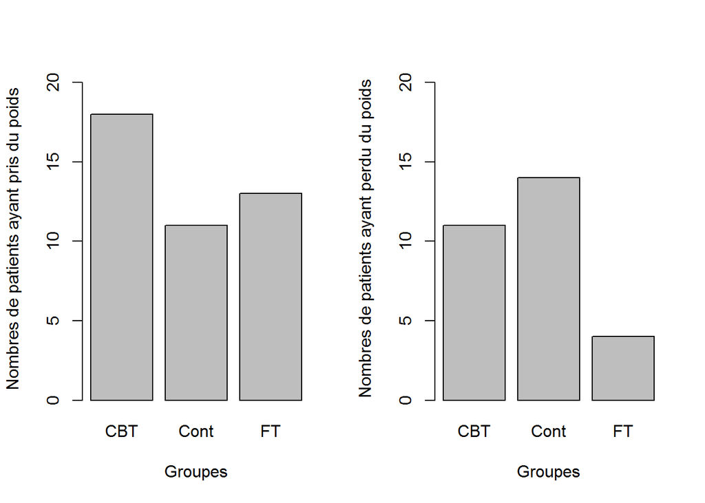

On voit qu’il y a:

**11** personnes sur **26** qui ont pris du poids dans le groupe **Cont** soit **42%** des personnes de ce groupe ont pris du poids et donc **54%** (14 personnes) qui en ont perdu et 1 personnes sur 26 donc **4%** qui a vu sont poids inchangé

**13** personnes sur **17** qui ont pris du poids dans le groupe **FT** soit **76%** des personnes de ce groupes ont pris du poids et donc (4 personnes), **24%** en ont perdu

**FT** a tendance à etre le traitement le plus efficace

**Pour comparer les 3 méthodes utilisons la fonction qqplot deux à deux pour A,B et C les changements de poids avant/après traitement pour les individus sous traitement Cont, CBT et FT respectivement**

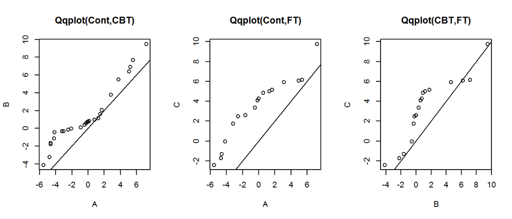

Avec le **Qqplot(Cont,CBT)** on voit que le changement de poids semble plus faible avec le traitement **“Cont”** qu’avec le traitement **“CBT”** car les nuages de points sont majoritairement à gauche de la bissectrices et donc proche de CBT on a une distribution plus forte du changement de poids.

Avec le **Qqplot(Cont,FT)** on voit que le changement de poids semble plus faible avec le traitement **“Cont”**qu’avec le traitement **“FT”**.

Avec le **Qqplot(CBT,FT)** on voit que le changement de poids semble plus faible avec le traitement**“CBT”**qu’avec le traitement **“FT”**.

**On considère maintenant le boxplot liée à la prise/perte de poids des différents groupes**

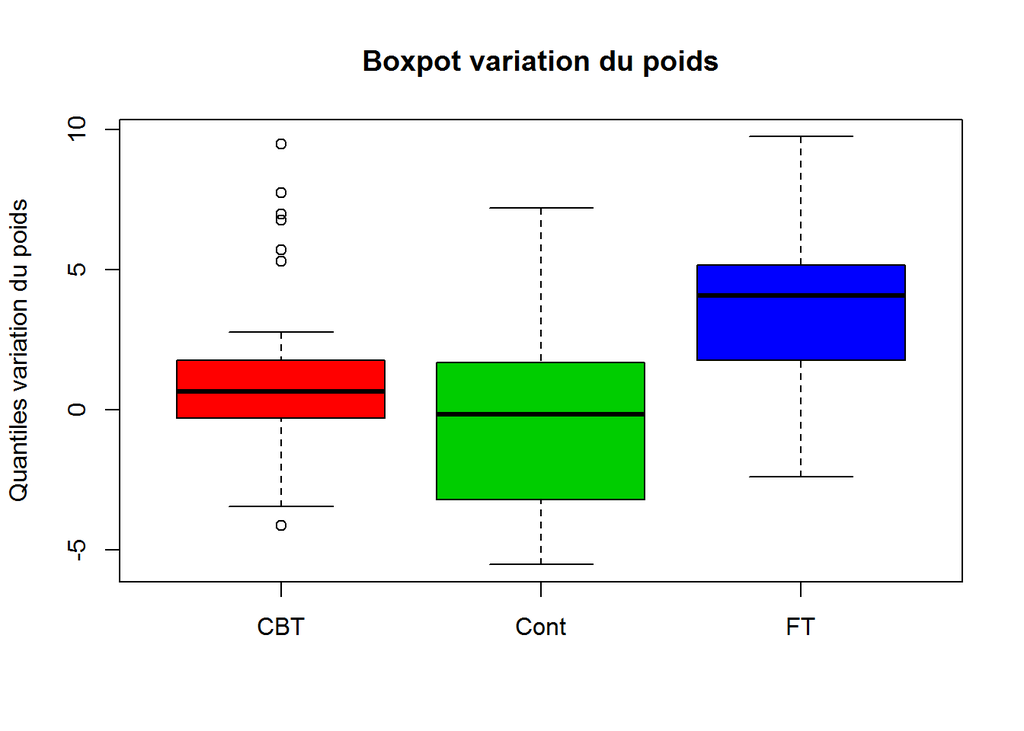

Résumé Boxplot de **CBT**

```
##    Min. 1st Qu.  Median    Mean 3rd Qu.    Max.
## -4.1223 -0.3171  0.6342  1.3621  1.7667  9.4677
```

Résumé Boxplot de **Cont**

```
##    Min. 1st Qu.  Median    Mean 3rd Qu.    Max.
## -5.5266 -3.1710 -0.1585 -0.2039  1.6308  7.2027
```

Résumé Boxplot de **FT**

```
##    Min. 1st Qu.  Median    Mean 3rd Qu.    Max.
##  -2.401   1.767   4.077   3.291   5.164   9.739
```

On en déduit de tout cela que la prise de poids semble plus fore avec le traitement **“FT”** on a meme une différence signivicatives par rapport aux 2 autres traitements, il semble etre le traitement le plus efficace pour la prise de poids des patients anorexiques dans cette étude

## Question 5

Analyser la distribution des différentes variables liées aux poids par type de traitement. Est-ce envisageable de les modéliser par une loi normale ?

Condiérons ces 3 Boxplots regroupant chacun des groupes pour analyser la distribution des différentes variables liées aux poids par type de traitement

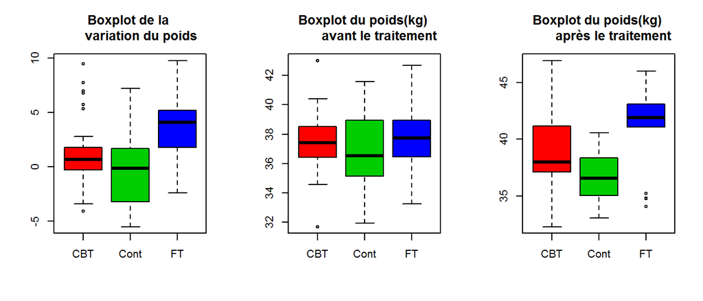

**Boxplot de la variation du poids**

Résumé Boxplot de **CBT**

```
##    Min. 1st Qu.  Median    Mean 3rd Qu.    Max.
## -4.1223 -0.3171  0.6342  1.3621  1.7667  9.4677
```

Résumé Boxplot de **Cont**

```
##    Min. 1st Qu.  Median    Mean 3rd Qu.    Max.
## -5.5266 -3.1710 -0.1585 -0.2039  1.6308  7.2027
```

Résumé Boxplot de **FT**

```
##    Min. 1st Qu.  Median    Mean 3rd Qu.    Max.
##  -2.401   1.767   4.077   3.291   5.164   9.739
```

On remarque que le boxplot de **CBT** est presque symérique la distribution de la variation du poids est à peu près symétrique la médiane et la moyenne sont légerement différentes à équales distance des quantiles 1 et 3. .Les 3 boxplots n’ont pas les memes médiane celle du groupe **Cont** est meme inféreur à zéro, on a quand meme une différence significative entre la distribution de la variation du poids dans le groupe **FT** et celles observé dans les autres groupes, on a aussi beaucoup plus de variabilité de la variance du poids pour les traitements **Cont** et **FT** que pour le traitement **CBT** groupe auquel on observes aussi des valeurs aberrantes (petits points isolées) dans la distribution de la variation du poids.

**Boxplot poids avant traitement**

Résumé Boxplot de **CBT**

```
##    Min. 1st Qu.  Median    Mean 3rd Qu.    Max.
##   31.71   36.42   37.42   37.46   38.51   42.99
```

Résumé Boxplot de **Cont**

```
##    Min. 1st Qu.  Median    Mean 3rd Qu.    Max.
##   31.94   35.21   36.53   36.95   38.90   41.59
```

Résumé Boxplot de ** FT**

```
##    Min. 1st Qu.  Median    Mean 3rd Qu.    Max.
##   33.25   36.47   37.73   37.70   38.96   42.67
```

On remarque avec les boxplots de **CBT** et **FT** que les distributions du poids avant traitements sont symétriques pour tout les 2 moyenne(Mean) et médiane sont quasiment identiques et un peu différentes pour **Cont** mais quand meme proche on a aussi beaucoup plus de variabilité de la distribution poids avant pour les traitements **Cont** et **FT** que pour le traitement **CBT**, on observe aussi des valeurs aberrantes dans la distribution du poids avant pour le groupe **CBT**

**Boxplot poids après traitement**

Résumé Boxplot de **CBT**

```
##    Min. 1st Qu.  Median    Mean 3rd Qu.    Max.
##   32.30   37.10   38.01   38.82   41.18   46.93
```

Résumé Boxplot de **Cont**

```
##    Min. 1st Qu.  Median    Mean 3rd Qu.    Max.
##   33.07   35.14   36.56   36.74   38.36   40.59
```

Résumé Boxplot de **FT**

```
##    Min. 1st Qu.  Median    Mean 3rd Qu.    Max.
##   34.07   41.09   41.90   40.99   43.13   46.02
```

**En ce qui concerne la normalité**

Soit:

A le vecteur des variations du poids pour thérapie pour **Cont**

B le vecteur des variations du poids pour thérapie pour **CBT**

C le vecteur des variations du poids pour thérapie pour **FT**

D le vecteur des poids avant la thérapie pour **Cont**

E le vecteur des poids avant la thérapie pour **CBT**

G le vecteur des poids avant la thérapie pour **FT**

H le vecteur des poids après la thérapie pour **Cont**

I le vecteur des poids après la thérapie pour **CBT**

J le vecteur des poids après la thérapie pour **FT**

**Voici les histogrammes de ces vecteurs superposé à la densité de la loi théorique:**

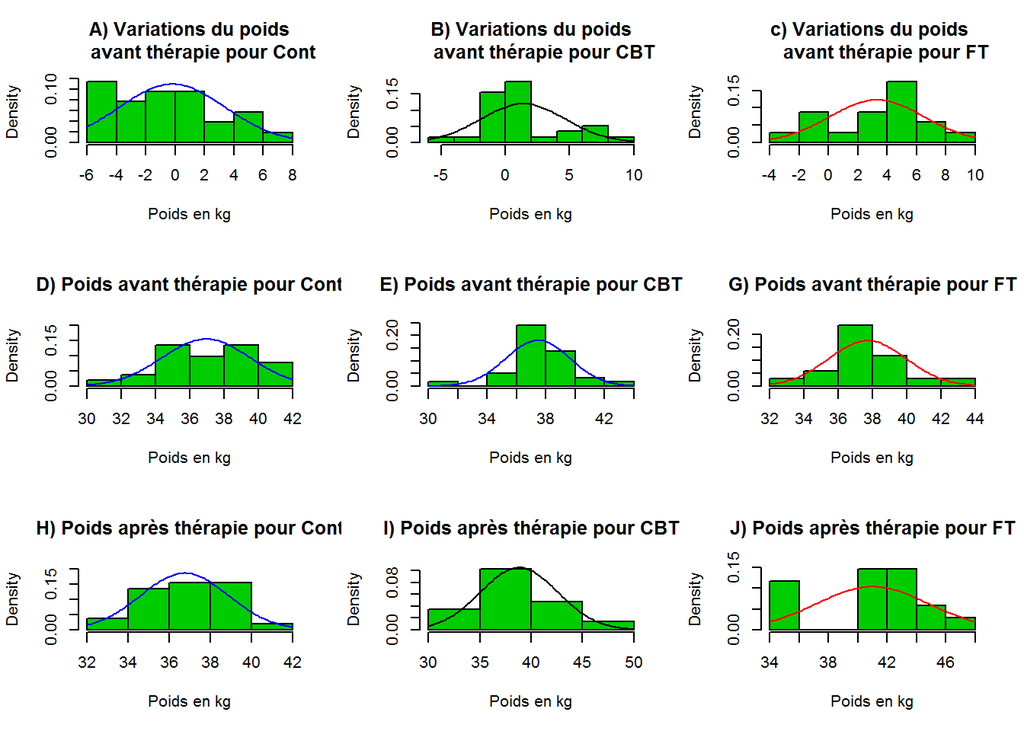

On remarque que tout les histogrammes sont (à peu près) unimodal sauf pour D H et J en particulier pour H et J les “pic” de l’histogramme sont bien trop larges pour une gaussienne et les histogrammes légèrement asymétrique pour tous. Etant donné que la taille de l’échantillon est petite pour chaque vecteur, la densité gaussienne semble appropriée (en tout cas on ne peut pas rejeter l’hypothèse gaussienne avec certitude pour l’ensembles des histogrammes.)

En effet en effectuant un test de Kolmogorov-Smirov pour chaque vecteurs(en les normalisant) nous obtenons ceci:

```
##
##  One-sample Kolmogorov-Smirnov test
##
## data:  a
## D = 0.094076, p-value = 0.9589
## alternative hypothesis: two-sided
```

```
##
##  One-sample Kolmogorov-Smirnov test
##
## data:  b
## D = 0.22275, p-value = 0.09587
## alternative hypothesis: two-sided
```

```
##
##  One-sample Kolmogorov-Smirnov test
##
## data:  c
## D = 0.12922, p-value = 0.905
## alternative hypothesis: two-sided
```

```
##
##  One-sample Kolmogorov-Smirnov test
##
## data:  d
## D = 0.098191, p-value = 0.9425
## alternative hypothesis: two-sided
```

```
##
##  One-sample Kolmogorov-Smirnov test
##
## data:  e
## D = 0.13069, p-value = 0.6573
## alternative hypothesis: two-sided
```

```
##
##  One-sample Kolmogorov-Smirnov test
##
## data:  g
## D = 0.10178, p-value = 0.9868
## alternative hypothesis: two-sided
```

```
##
##  One-sample Kolmogorov-Smirnov test
##
## data:  h
## D = 0.095835, p-value = 0.9523
## alternative hypothesis: two-sided
```

```
##
##  One-sample Kolmogorov-Smirnov test
##
## data:  i
## D = 0.15978, p-value = 0.4068
## alternative hypothesis: two-sided
```

```
##
##  One-sample Kolmogorov-Smirnov test
##
## data:  j
## D = 0.2744, p-value = 0.1271
## alternative hypothesis: two-sided
```

**Observons maintenant les qqpnorm pour avoir plus de certitudes**

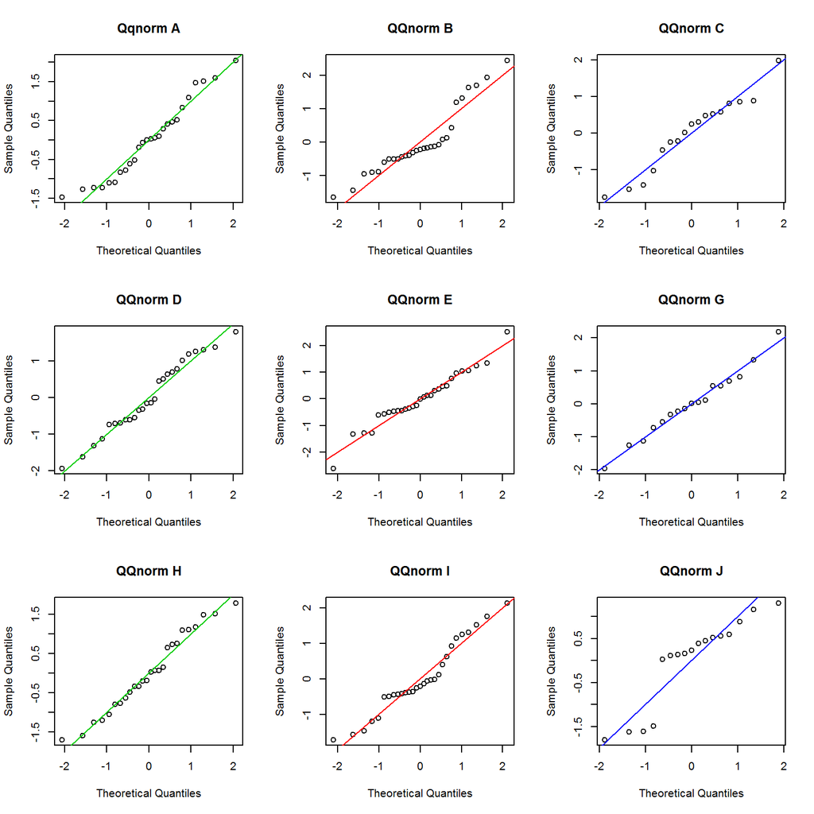

On voit que tous les vecteurs semblent suivrent une loi normales(car les points semblent s’alligner sur la bissectrice dans les graphiques) sauf pour le vecteur **J** pour les vecteurs **B** **I** et **E** su groupes **CBT** certains points s’éloigne de la bisectrice mais pas au point de rejetr l’hypothèse gausienne

**Donc l’ensembles des variables liées aux poids par type de traitement peuvent etre modéliser par une loi normales sauf pour le vecteur du poids après traitement pour le groupe FT**

On aurait pu regarder les fonctions de répartitions ou l’ont voit que l’adéquation entre la fonction de répartition empirique et la fonction de répartition théorique est très bonne pour l’ensemble des vecteurs (y compris **E** un peu moins bonne pour **B** et **I** . .133mais correcte) sauf pour **J** .

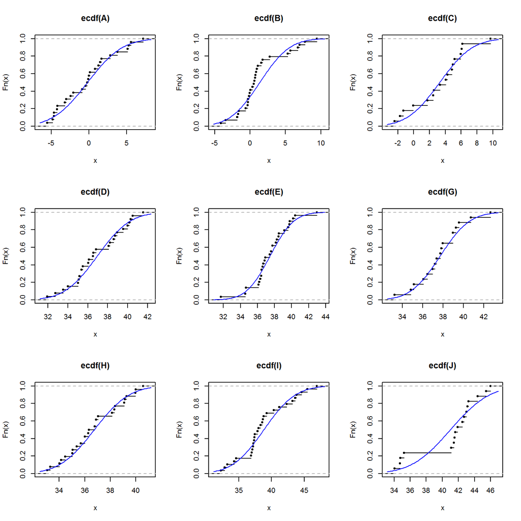

## Question 6

Donner votre conclusion.

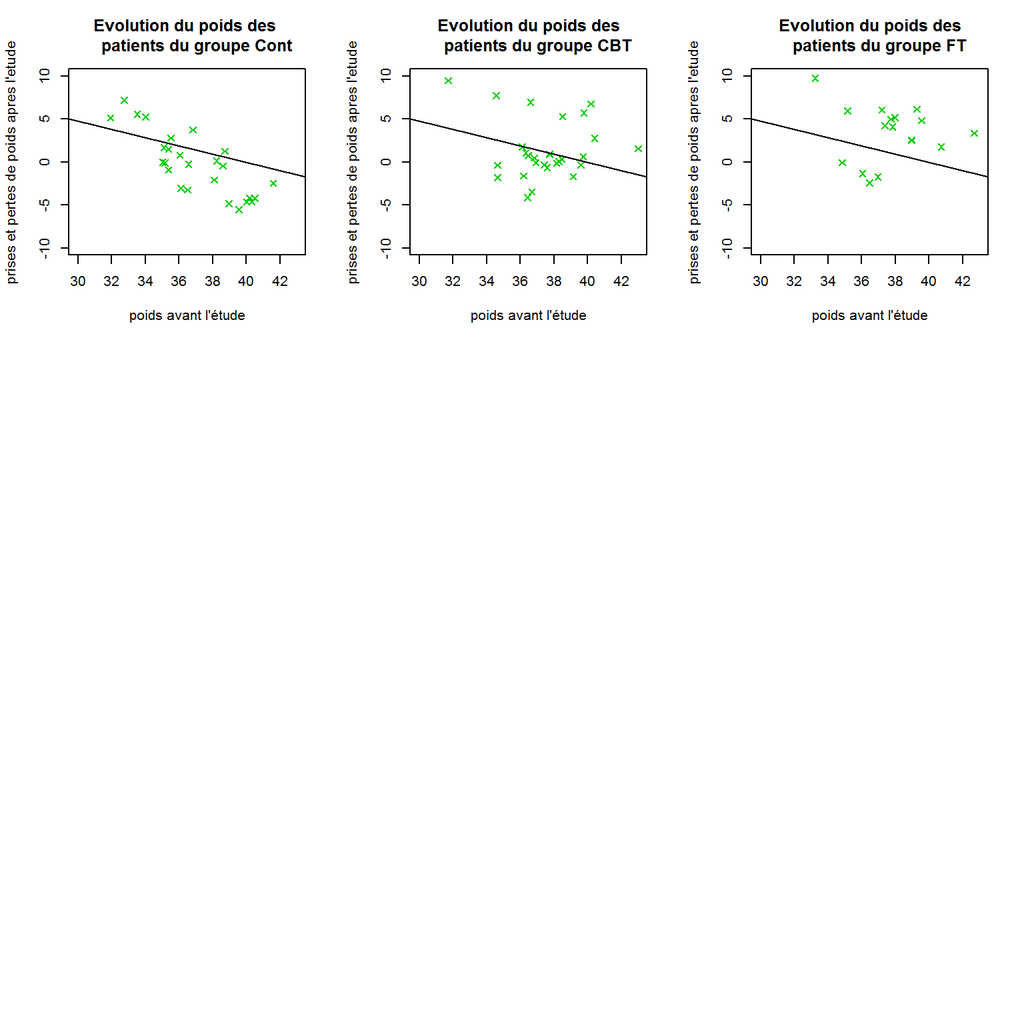